# BankMarketing

### II - The Problem

The task is to analyze the data set of customers provided by the banking institution, and determine what combination of personal characteristics and external factors are associated with the highest likelihood calling a client who will subscribe to a term deposit.

The observations in the data set represent calls made to potential and existing clients of the bank, and the attributes describe the personal characteristics of the clients themselves(age, marital status, etc), the marketing behavior of the bank(e.g. number of contacts made by bank, time of year), as well as the economic climate at the time of the call(e.g. consumer confidence index).

Most importantly, these calls have an indicating variable for whether or not the call resulted in the client subscribing to a term deposit, which is ultimately the reason the bank is making the calls.

Ascertaining which factors are most correlated with subscribing to term deposits will allow the bank to save time and money by focusing on clients that are likely to subscribe, and avoiding those that are not.

The following sections will describe in greater detail the nature of the data set and related literature as well as the methodology used to produce the predictive model with the most utility for the bank.

## III - Review of Related Literature

There were few Marketing Analysis happened with this bank marketing data set and based upon the usage of various exploration, prediction techniques and hyper parameter optimization, different analysis came with different conclusion and Recommendation. As per the Journal of Visualization and Analysis in bank Direct marketing prediction by Alaa abu-srhan, based on the exploratory data analysis , different oversampling methods such as Synthetic Minority Oversampling technique, Random Over Oversampling Technique, Selective Pre-processing, etc are used to overcome the imbalance in the response variable which in turn increase prediction accuracy from various classification prediction techniques. Following are the classification techniques,(Random forest, support vector machine (SVM), neural network (NN), Naive Bayes,and k-nearest neighbor (KNN) classifiers), are used for the analysis and the results are compared on Gmean and accuracy evaluation metrics to identify the best results.As per the conclusion, SVM and Naive Bayes Classifier provides a better accuracy and Gmean values.

Similarly in Data Mining- Bank Marketing Data set by “Kinga Włodarczyk”, Different classifier Techniques such as KNN, Linear and logistic regression models have created using different dependent variables in order to predict the response by comparing the accuracy.

In this analysis we are also going to try different classification techniques such as logistic regression, random forest, support vector machines with different hyper parameters and different predictors and compare the results based on the accuracy in order to identify the appropriate model.

## IV - Methodology

We will test four types of classifier and compare the results to determine which will best serve to predict a successful call. These models are as follows: Logistic Regression, Random Forest, Decision Tree, and Linear Support Vector Machine.

Prior to the training process for any of the models the variables are selected and modified for more efficient computation and accurate results. Variables that lack predictive value are removed, and numeric data describing unrelated phenomena are scaled to condense the dimensional space for the calculations.

The data then needs to be balanced for the target class, because with the unmodified data set a classifier could achieve 90% accuracy by predicting a ‘no’ response for every observation. A balanced training set is created by resampling the “yes” observations to match the quantity of “no” observations. However, after the classifier is trained, it will be tested on the unbalanced test set in order to determine how the classifier would perform under real conditions.

The entire reason the bank is calling people is in the hope of finding potential customers, so a model that only predicts “no” is useless even if it may be very accurate.

After the data is prepared and divided into a balanced training set and unbalanced test set, important variables are determined first by performing stepwise selection using AIC for a logistic regression using a full model.

### V - Data

The data set to be used is a representative sample of the larger banking data set called ‘bank-additional.csv’, with additional being a reference to the quarterly economic indicators that are included in addition to the banking client data.

As is outlined in the data dictionary, “duration” serves no predictive purpose, because it can only be known after the call is made, and can’t be used in the decision for which customer to call, so it is removed. Also removed is the pdays variable which represents the number of days that have passed since the client was last called. This variable lacks sufficient variance to provide meaningful predictive value because the dummy value of 999 given to signify a call to a new customer is so numerous and so far from the real values.

```r
table(bank$pdays)
```

```
##
##    0    1    2    3    4    5    6    7    9   10   11   12   13   14   15   16
##    2    3    4   52   14    4   42   10    3    8    1    5    2    1    2    2
##   17   18   19   21  999
##    1    2    1    1 3959
```

After the data is preprocessed, we examine the predictors that have the highest significance in a full logistic regression model.

```
##                       Estimate Std. Error   z value     Pr(>|z|)
## poutcomesuccess     -2.0788136 0.22149155 -9.385521 6.260627e-21
## cons.conf.idx       -0.3969843 0.05400436 -7.350967 1.967779e-13
## contacttelephone     1.1159471 0.16178292  6.897806 5.281198e-12
## month3              -2.7813705 0.42635458 -6.523609 6.863558e-11
## jobmanagement        0.9710234 0.16270282  5.968080 2.400618e-09
## campaign             0.3068188 0.05282054  5.808703 6.295858e-09
## cons.price.idx      -1.3929925 0.27003108 -5.158638 2.487531e-07
## emp.var.rate         2.1737610 0.45715059  4.755022 1.984250e-06
## jobself-employed     0.9635472 0.22432101  4.295395 1.743829e-05
## age                 -0.1852449 0.04475575 -4.139019 3.487943e-05
## day_of_week4         0.4357118 0.10766792  4.046811 5.192005e-05
## day_of_week2         0.4147762 0.10863476  3.818080 1.344944e-04
## poutcomenonexistent -0.4292154 0.11874989 -3.614448 3.009877e-04
## day_of_week5         0.3902582 0.10992854  3.550108 3.850732e-04
## housingunknown       0.9737736 0.31156390  3.125438 1.775406e-03
```

[output not shown]

The most important variables in the full logistic regression model are the same as the variables with the lowest p-values when using stepwise predictor selection, which makes sense.

Next we will examine the distribution of the “yes” and “no” class across these significant variables.

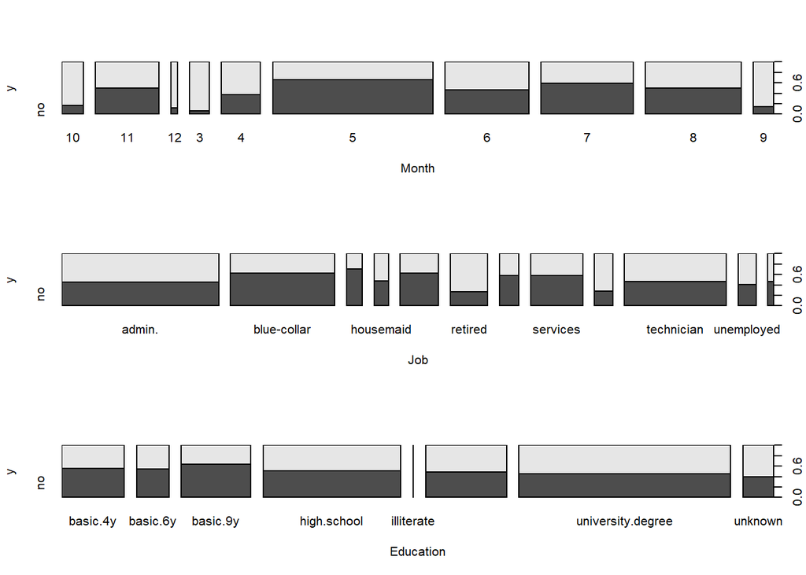

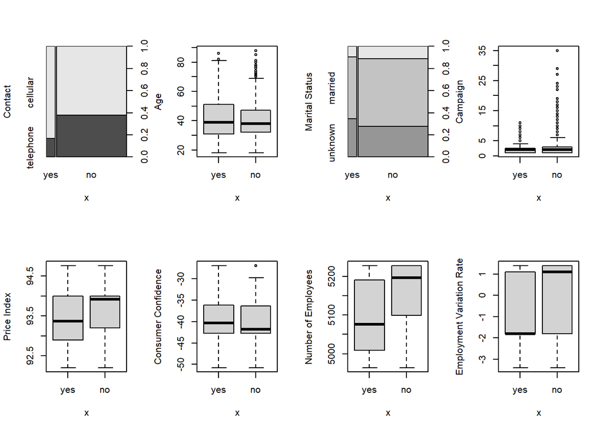

We can see that, perhaps surprisingly, the apparently strongest difference in means are in the aggregate economic indicators rather than the most of the individual personal data. This can potentially be a problem, because while the strength of the economic statistics as predictors can result in a more accurate model using training data, a prediction model that relies heavily on variables out of control of the bank is not useful to the bank when trying to decide who to call.

### VI - Findings

The confusion matrices and accuracy statistics from the models are listed below:

```
## [1] "Personal Logistic Regression"
##           Reference
## Prediction yes  no
##        yes  84 413
##        no   57 682
##    Pos Pred Value Balanced Accuracy
##         0.1690141         0.6092879
##
## [1] "Full Model Logistic Regression"
##           Reference
## Prediction yes  no
##        yes  74 151
##        no   67 944
##    Pos Pred Value Balanced Accuracy
##         0.3288889         0.6934616
##
## [1] "Personal Decision Tree"
##           Reference
## Prediction yes  no
##        yes 103 546
##        no   38 549
##    Pos Pred Value Balanced Accuracy
##         0.1587057         0.6159332
##
## [1] "Full Decision Tree"
##           Reference
## Prediction  yes   no
##        yes   61   84
##        no    80 1011
##    Pos Pred Value Balanced Accuracy
##         0.4206897         0.6779559
##
## [1] "Full Linear SVC"
##           Reference
## Prediction yes  no
##        yes  74 151
##        no   67 944
##    Pos Pred Value Balanced Accuracy
##         0.3288889         0.6934616
##
## [1] "Personal Random Forest"
##           Reference
## Prediction  yes   no
##        yes   17   65
##        no   124 1030
##    Pos Pred Value Balanced Accuracy
##         0.2073171         0.5306033
##
## [1] "Full Random Forest"
##           Reference
## Prediction  yes   no
##        yes   43   55
##        no    98 1040
##    Pos Pred Value Balanced Accuracy
##         0.4387755         0.6273681
```

Clearly the highest levels of both accuracy and rate of successful positive prediction are in the models that use all of the variables, and so these models provide the best predictive performance when viewed at face value. However, the variable importance reveals the source of the high predictive value in the decision tree, SVC, and random forest is based on the quarterly economic indicators:

```
## [1] "Logistic Regression Variable Importance"
```

```
## glmnet variable importance
##
##   only 20 most important variables shown (out of 51)
##
##                     Overall
## educationilliterate 100.000
## month3               59.826
## poutcomesuccess      50.017
## defaultyes           40.115
## emp.var.rate         29.690
## contacttelephone     23.174
## jobmanagement        22.532
## jobself-employed     22.320
## maritalunknown       22.081
## housingunknown       21.747
## cons.price.idx       20.086
## month12              15.462
## jobentrepreneur      10.490
## month9               10.481
## poutcomenonexistent   9.965
## day_of_week4          9.514
## day_of_week2          9.208
## day_of_week5          8.610
## cons.conf.idx         8.417
## educationbasic.6y     8.145
```

```
## [1] "Decision Tree Variable Importance"
```

```
## rpart variable importance
##
##   only 20 most important variables shown (out of 51)
##
##                      Overall
## nr.employed           100.00
## euribor3m              89.58
## emp.var.rate           79.59
## poutcomesuccess        46.12
## previous               36.37
## educationhigh.school    0.00
## housingunknown          0.00
## jobunemployed           0.00
## educationunknown        0.00
## month3                  0.00
## `jobself-employed`      0.00
## loanunknown             0.00
## housingyes              0.00
## month11                 0.00
## day_of_week3            0.00
## defaultyes              0.00
## maritalunknown          0.00
## `jobblue-collar`        0.00
## campaign                0.00
## educationilliterate     0.00
```

```
## [1] "Random Forest Variable Importance"
```

[output not shown]

```
## [1] "Linear SVM Variable Importance"
```

[output not shown]

The high importance value for the illiterate education category is not as concerning for the logistic model, because it represents only one observation in the original data set and thus is not relevant in any likely test or production data.

When the deciding factors for calling the client are mainly external economic indicators, the bank can be left in a situation where the model is recommending to make no calls because the national statistics aren’t favorable. The advantage of the flexibility of the model based on personal attributes vs the tree that includes the indicators is obvious:

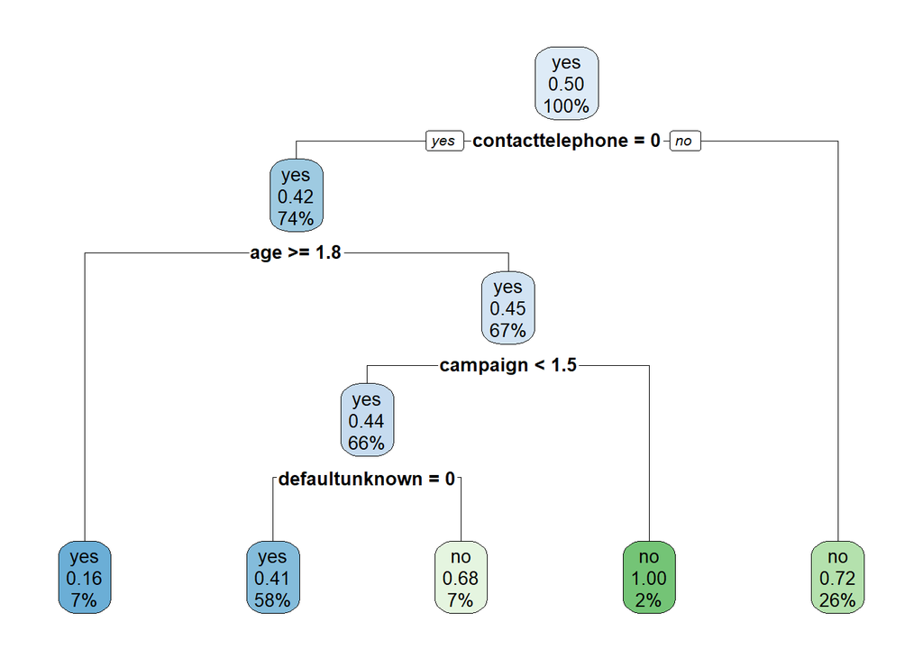

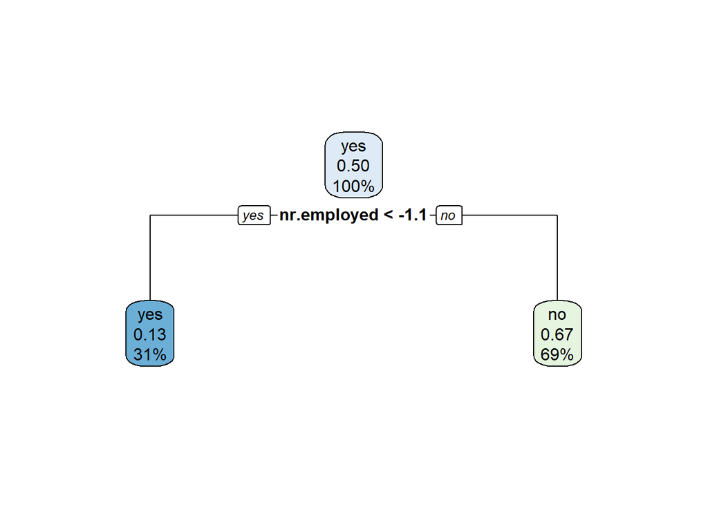

### VII - Conclusions

The chart below displays the range of cost ratios at which a given model will still provide profitable predictions.

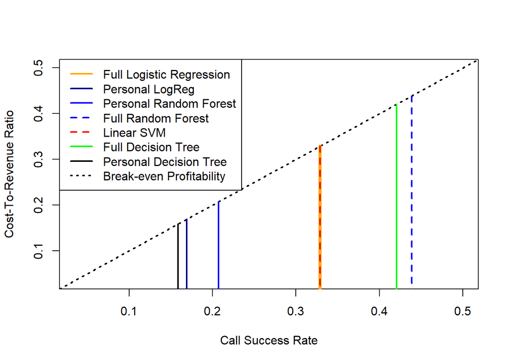

Overall, assuming the bank has the option to do so, the full logistic regression model provides the predictions that will accommodate the widest range of cost-to-revenue ratios without an excessive reliance on external variables.

### Appendix

#### Preprocessing the data

```r
set.seed(12345)
bank<-read.csv('bank-additional.csv',sep=";",stringsAsFactors = T)
sum(is.na(bank))
#duration in column 11
bank<-bank[-11]

#replace month abbreviations with numbers
monthord<-as.character(bank$month)
mn<-c('jan','feb','mar','apr','may','jun','jul',
  'aug','sep','oct','nov','dec')
md<-c(1,2,3,4,5,6,7,8,9,10,11,12)
monthord[monthord %in% mn] <- md[match(monthord, mn)]
bank$month<-as.factor(monthord)

#replace day of week abbreviations with numbers
weekord<-as.character(bank$day_of_week)
mn<-c('mon','tue','wed','thu','fri','sat','sun')
md<-c(1,2,3,4,5,6,7)
weekord[weekord %in% mn] <- md[match(weekord, mn)]
bank$day_of_week<-as.factor(weekord)

#reverse levels so "yes" is returned as the positive class to the caret model
bank$y <- factor(bank$y, levels=rev(levels(bank$y)))


#scale and remove variables with near-zero variance(which turns out to be pdays)

params<-preProcess(bank,method=c("scale","center","nzv"))
scaledbank<-predict(params,bank)

#separate the data into train and test sets

train<-sample(nrow(scaledbank),0.7*nrow(scaledbank))
banktrain<-scaledbank[train,]
banktest<-scaledbank[-train,]

#balance the target classes so the
banktrain<-upSample(x=banktrain[,-ncol(banktrain)],y=banktrain$y)
```

#### Determining most significant variables

```r
##train logistic regressino and select variables by significance
fullmodel<-glm(Class~.,banktrain,family=binomial)

stepped<-stepAIC(fullmodel, direction = "both",trace = FALSE)

idx <- order(coef(summary(stepped))[,4])
out <- coef(summary(stepped))[idx,]
head(out,15)

###importance
imp <- as.data.frame(varImp(fullmodel))
imp <- data.frame(Importance = imp$Overall,
           Variable_Name   = rownames(imp))
head(imp[order(imp$Importance,decreasing = T),],10)
```

#### Training different models

```r
#TC <- trainControl(method = "boot", number=50,classProbs=TRUE,summaryFunction = twoClassSummary)
TC <- trainControl(method="repeatedcv", number=10,repeats=3,classProbs=TRUE,summaryFunction = twoClassSummary)



bankrf <- train(Class~poutcome+job+loan+contact+campaign+month+cons.price.idx+cons.conf.idx+emp.var.rate+education+day_of_week, data=banktrain,
                 method = "rf",
                 metric="ROC",
                 trControl = TC)

predrf<-predict(bankrf,banktest)


banktree=train(Class~.,data=banktrain, metric="Spec",trControl=TC,method='rpart',
               control = rpart.control(cp=0.01, split=c("gini"),minbucket = 5))
predtree<-predict(banktree,banktest)




bankLOG <- train(Class~previous+contact+campaign+cons.price.idx+cons.conf.idx+emp.var.rate+education+day_of_week, data=banktrain,
                 method = "glmnet",
                 metric="ROC",
                 trControl = TC)

predlog<-predict(bankLOG,banktest)


bankLOGfull <- train(Class~., data=banktrain,
                 method = "glmnet",
                 metric="ROC",
                 trControl = TC)

predlogfull<-predict(bankLOGfull,banktest)



TC <- trainControl(method="repeatedcv", number=10,repeats=3,
                   classProbs=TRUE,summaryFunction = twoClassSummary)

bankrad <- train(Class~poutcome+job+contact+campaign+month+cons.price.idx+cons.conf.idx+emp.var.rate, data=banktrain,
                 method = "svmLinear",
                 metric="ROC",
                 trControl = TC,
                 tuneGrid = expand.grid(C = seq(0.01, 2, length = 10)))


predrad<-predict(bankrad,banktest)
```

#### Model output

```r
bankLOG
```

[output not shown]

```r
bankLOGfull
```

[output not shown]

```r
banktree
```

[output not shown]

```r
bankrf
```

[output not shown]

```r
bankrad
```

[output not shown]